# Team Assignment - Group 065

*Team Members: Christian Heinzig, Kannan Anil Kumar,Thandekile Rebecca Simelane, Sabrina Rahman, Kenny Le, Stone Gomberg*

## 1. Import Programming Modules

```python
# %pip install pyarrow
import pandas as pd
import matplotlib.pyplot as plt
```

## 2. Load ities.parquet into dfi, display information, first 5 rows

```python
dfi = pd.read_parquet('ities.parquet')
dfi.info()
dfi.head()
```

```
<class 'pandas.DataFrame'>
RangeIndex: 438151 entries, 0 to 438150
Data columns (total 13 columns):
 #   Column             Non-Null Count   Dtype
---  ------             --------------   -----
 0   Date               438151 non-null  str
 1   OperationType      438151 non-null  str
 2   CashierName        438151 non-null  str
 3   LineItem           438151 non-null  str
 4   Department         438151 non-null  str
 5   Category           438151 non-null  str
 6   RegisterName       438151 non-null  str
 7   StoreNumber        438151 non-null  str
 8   TransactionNumber  438151 non-null  str
 9   CustomerCode       438151 non-null  str
 10  Price              438139 non-null  float64
 11  Quantity           438151 non-null  int64
 12  TotalDue           438139 non-null  float64
dtypes: float64(2), int64(1), str(10)
memory usage: 85.7 MB
```

|  | Date | OperationType | CashierName | LineItem | Department | Category | RegisterName | StoreNumber | TransactionNumber | CustomerCode | Price | Quantity | TotalDue |
| --- | --- | --- | --- | --- | --- | --- | --- | --- | --- | --- | --- | --- | --- |
| 0 | 7/18/2016 | SALE | Wallace Kuiper | Salmon and Wheat Bran Salad | Entrees | Salmon and Wheat Bran Salad | RT149 | AZ23501305 | 002XIIC146121 | CWM11331L8O | 66.22 | 1 | 66.22 |
| 1 | 7/18/2016 | SALE | Wallace Kuiper | Fountain Drink | Beverage | Fountain | RT149 | AZ23501289 | 002XIIC146121 | CWM11331L8O | 2.88 | 1 | 2.88 |
| 2 | 7/18/2016 | SALE | Wallace Kuiper | Beef and Squash Kabob | Kabobs | Beef | RT149 | AZ23501367 | 00PG9FL135736 | CWM11331L8O | 12.02 | 2 | 24.04 |
| 3 | 7/18/2016 | SALE | Wallace Kuiper | Salmon and Wheat Bran Salad | Salad | general | RT149 | AZ23501633 | 00Z3B4R37335 | CWM11331L8O | 18.43 | 1 | 18.43 |
| 4 | 7/18/2016 | SALE | Wallace Kuiper | Salmon and Wheat Bran Salad | Salad | general | RT149 | AZ23501633 | 00Z3B4R37335 | CWM11331L8O | 18.43 | 1 | 18.43 |

## 3. Load max_temp.pickle file into dfw, display information, first 5 rows

```python
dfw = pd.read_pickle('max_temp.xz')
dfw.info()
dfw.head()
```

```
<class 'pandas.DataFrame'>
RangeIndex: 52 entries, 0 to 51
Data columns (total 9 columns):
 #   Column        Non-Null Count  Dtype
---  ------        --------------  -----
 0   Week          52 non-null     int64
 1   Monday        52 non-null     float64
 2   Tuesday       52 non-null     float64
 3   Wednesday     52 non-null     float64
 4   Thursday      52 non-null     float64
 5   Friday        52 non-null     float64
 6   Saturday      52 non-null     float64
 7   Sunday        52 non-null     float64
 8   WeekStarting  52 non-null     object
dtypes: float64(7), int64(1), object(1)
memory usage: 3.8+ KB
```

|  | Week | Monday | Tuesday | Wednesday | Thursday | Friday | Saturday | Sunday | WeekStarting |
| --- | --- | --- | --- | --- | --- | --- | --- | --- | --- |
| 0 | 1 | 46.94 | 44.96 | 41.00 | 44.96 | 59.00 | 57.02 | 57.02 | 1/3/2016 |
| 1 | 2 | 48.92 | 46.04 | 46.04 | 46.94 | 51.08 | 42.08 | 48.92 | 1/10/2016 |
| 2 | 3 | 48.02 | 51.98 | 53.06 | 55.04 | 50.00 | 51.08 | 50.00 | 1/17/2016 |
| 3 | 4 | 33.98 | 41.00 | 51.08 | 46.94 | 55.94 | 51.08 | 35.96 | 1/24/2016 |
| 4 | 5 | 51.08 | 60.08 | 57.92 | 51.08 | 41.00 | 48.02 | 51.98 | 1/31/2016 |

## 4. Convert Data Types

```python
# Convert the date columns from object to datetime
dfi['Date'] = pd.to_datetime(dfi['Date'])
dfi.info()
dfw['WeekStarting'] = pd.to_datetime(dfw['WeekStarting'])
dfw.info()
```

```
<class 'pandas.DataFrame'>
RangeIndex: 438151 entries, 0 to 438150
Data columns (total 13 columns):
 #   Column             Non-Null Count   Dtype
---  ------             --------------   -----
 0   Date               438151 non-null  datetime64[us]
 1   OperationType      438151 non-null  str
 2   CashierName        438151 non-null  str
 3   LineItem           438151 non-null  str
 4   Department         438151 non-null  str
 5   Category           438151 non-null  str
 6   RegisterName       438151 non-null  str
 7   StoreNumber        438151 non-null  str
 8   TransactionNumber  438151 non-null  str
 9   CustomerCode       438151 non-null  str
 10  Price              438139 non-null  float64
 11  Quantity           438151 non-null  int64
 12  TotalDue           438139 non-null  float64
dtypes: datetime64[us](1), float64(2), int64(1), str(9)
memory usage: 82.0 MB
<class 'pandas.DataFrame'>
RangeIndex: 52 entries, 0 to 51
Data columns (total 9 columns):
 #   Column        Non-Null Count  Dtype
---  ------        --------------  -----
 0   Week          52 non-null     int64
 1   Monday        52 non-null     float64
 2   Tuesday       52 non-null     float64
 3   Wednesday     52 non-null     float64
 4   Thursday      52 non-null     float64
 5   Friday        52 non-null     float64
 6   Saturday      52 non-null     float64
 7   Sunday        52 non-null     float64
 8   WeekStarting  52 non-null     datetime64[us]
dtypes: datetime64[us](1), float64(7), int64(1)
memory usage: 3.8 KB
```

The Date and WeekStarting columns were converted from object to datetime because later tasks require date calculations, sorting, and joining. No other conversions were necessary because the remaining columns already had appropriate datatypes or did not require any datatype conversions for subsequent operations.

## 5. Display Summary Statistics

```python
dfi.describe(include='all')
```

|  | Date | OperationType | CashierName | LineItem | Department | Category | RegisterName | StoreNumber | TransactionNumber | CustomerCode | Price | Quantity | TotalDue |
| --- | --- | --- | --- | --- | --- | --- | --- | --- | --- | --- | --- | --- | --- |
| count | 438151 | 438151 | 438151 | 438151 | 438151 | 438151 | 438151 | 438151 | 438151 | 438151 | 438139.000000 | 438151.000000 | 438139.000000 |
| unique | NaN | 2 | 56 | 68 | 9 | 21 | 12 | 70 | 161058 | 9110 | NaN | NaN | NaN |
| top | NaN | SALE | Wallace Kuiper | Salmon and Wheat Bran Salad | Entrees | Salmon and Wheat Bran Salad | RT149 | AZ23501305 | 00XHLAF147696 | CWM11331L8O | NaN | NaN | NaN |
| freq | NaN | 437802 | 79328 | 89051 | 152575 | 72601 | 160786 | 72601 | 64 | 393645 | NaN | NaN | NaN |
| mean | 2015-07-11 03:19:15.177096 | NaN | NaN | NaN | NaN | NaN | NaN | NaN | NaN | NaN | 14.359193 | 1.177375 | 15.255536 |
| min | 2014-01-04 00:00:00 | NaN | NaN | NaN | NaN | NaN | NaN | NaN | NaN | NaN | -5740.510000 | 1.000000 | -5740.510000 |
| 25% | 2014-09-11 00:00:00 | NaN | NaN | NaN | NaN | NaN | NaN | NaN | NaN | NaN | 4.500000 | 1.000000 | 4.500000 |
| 50% | 2015-06-26 00:00:00 | NaN | NaN | NaN | NaN | NaN | NaN | NaN | NaN | NaN | 11.290000 | 1.000000 | 11.800000 |
| 75% | 2016-04-26 00:00:00 | NaN | NaN | NaN | NaN | NaN | NaN | NaN | NaN | NaN | 14.680000 | 1.000000 | 15.040000 |
| max | 2017-04-05 00:00:00 | NaN | NaN | NaN | NaN | NaN | NaN | NaN | NaN | NaN | 21449.970000 | 815.000000 | 21449.970000 |
| std | NaN | NaN | NaN | NaN | NaN | NaN | NaN | NaN | NaN | NaN | 92.024361 | 1.856216 | 92.777518 |

```python
dfw.describe(include='all')
```

|  | Week | Monday | Tuesday | Wednesday | Thursday | Friday | Saturday | Sunday | WeekStarting |
| --- | --- | --- | --- | --- | --- | --- | --- | --- | --- |
| count | 52.000000 | 52.000000 | 52.000000 | 52.000000 | 52.000000 | 52.000000 | 52.000000 | 52.000000 | 52 |
| mean | 26.500000 | 68.287308 | 68.117692 | 69.187308 | 69.408846 | 70.682692 | 70.575385 | 69.246154 | 2016-06-29 12:00:00 |
| min | 1.000000 | 33.980000 | 28.940000 | 30.920000 | 30.920000 | 33.080000 | 28.940000 | 33.980000 | 2016-01-03 00:00:00 |
| 25% | 13.750000 | 48.920000 | 50.000000 | 51.980000 | 50.540000 | 55.445000 | 53.960000 | 51.980000 | 2016-04-01 06:00:00 |
| 50% | 26.500000 | 67.460000 | 68.000000 | 65.930000 | 67.010000 | 65.030000 | 68.540000 | 70.520000 | 2016-06-29 12:00:00 |
| 75% | 39.250000 | 88.295000 | 87.575000 | 89.285000 | 89.555000 | 91.265000 | 89.555000 | 89.960000 | 2016-09-26 18:00:00 |
| max | 52.000000 | 100.940000 | 100.940000 | 102.020000 | 100.940000 | 104.000000 | 102.020000 | 102.920000 | 2016-12-25 00:00:00 |
| std | 15.154757 | 21.052842 | 20.981918 | 21.091493 | 21.629795 | 20.008970 | 20.037787 | 20.651924 | NaN |

## 6. Identify and Handle Missing Values, Defend reasoning

```python
dfi.isna().sum()
```

```
Date                  0
OperationType         0
CashierName           0
LineItem              0
Department            0
Category              0
RegisterName          0
StoreNumber           0
TransactionNumber     0
CustomerCode          0
Price                12
Quantity              0
TotalDue             12
dtype: int64
```

```python
# Remove rows missing Price or TotalDue
dfi = dfi.dropna(subset=['Price', 'TotalDue']).reset_index(drop=True)

# Verify that the missing values were removed by printing count of missing values again
dfi.isna().sum()
```

```
Date                 0
OperationType        0
CashierName          0
LineItem             0
Department           0
Category             0
RegisterName         0
StoreNumber          0
TransactionNumber    0
CustomerCode         0
Price                0
Quantity             0
TotalDue             0
dtype: int64
```

The 12 rows with missing Price and TotalDue values were removed because they represented less than 0.003% of the dataset. Imputing both values could introduce inaccurate sales amounts.

## 7. Aggregate dfi at the Daily Level, display first 10 rows, defend reasoning

```python
dfid = (
    dfi.groupby('Date')[['Quantity', 'TotalDue']]
       .sum()
       .reset_index()
)

dfid.head(10)
```

|  | Date | Quantity | TotalDue |
| --- | --- | --- | --- |
| 0 | 2014-01-04 | 593 | 6748.21 |
| 1 | 2014-01-06 | 345 | 7455.73 |
| 2 | 2014-01-07 | 410 | 5472.79 |
| 3 | 2014-01-08 | 413 | 4128.62 |
| 4 | 2014-01-09 | 420 | 5568.43 |
| 5 | 2014-01-10 | 656 | 6931.44 |
| 6 | 2014-01-11 | 695 | 7362.49 |
| 7 | 2014-01-13 | 270 | 3096.02 |
| 8 | 2014-01-14 | 404 | 4580.24 |
| 9 | 2014-01-15 | 632 | 8030.54 |

Sum was used for quantity to calculate the total quantity recorded each day, and for TotalDue to calculate daily net sales including the effect of returns or refunds. Sum was chosen as the aggregate measures since the total quantity and total sales amount for each day is of interest to the analysis.

## 8. Create dfwd by converting dfw from wide to long format, display first 10 rows

```python
dfwd = dfw.melt(
    id_vars=['Week', 'WeekStarting'],
    value_vars=[
        'Monday', 'Tuesday', 'Wednesday', 'Thursday', 'Friday', 'Saturday', 'Sunday'
    ],
    var_name='day',
    value_name='max_temp'
)
dfwd.head(10)
```

|  | Week | WeekStarting | day | max_temp |
| --- | --- | --- | --- | --- |
| 0 | 1 | 2016-01-03 | Monday | 46.94 |
| 1 | 2 | 2016-01-10 | Monday | 48.92 |
| 2 | 3 | 2016-01-17 | Monday | 48.02 |
| 3 | 4 | 2016-01-24 | Monday | 33.98 |
| 4 | 5 | 2016-01-31 | Monday | 51.08 |
| 5 | 6 | 2016-02-07 | Monday | 55.94 |
| 6 | 7 | 2016-02-14 | Monday | 48.92 |
| 7 | 8 | 2016-02-21 | Monday | 42.08 |
| 8 | 9 | 2016-02-28 | Monday | 44.96 |
| 9 | 10 | 2016-03-06 | Monday | 41.00 |

## 9. Create and Sort the Date Column in dfwd

```python
# Number of days after WeekStarting
day_offsets = {
    'Sunday': 0,
    'Monday': 1,
    'Tuesday': 2,
    'Wednesday': 3,
    'Thursday': 4,
    'Friday': 5,
    'Saturday': 6
}

# Create the Date column
dfwd['Date'] = (
    dfwd['WeekStarting']
    + pd.to_timedelta(dfwd['day'].map(day_offsets), unit='D')
)

# Sort the DataFrame by Date
dfwd = dfwd.sort_values('Date').reset_index(drop=True)

# Display the first 10 rows
dfwd.head(10)
```

|  | Week | WeekStarting | day | max_temp | Date |
| --- | --- | --- | --- | --- | --- |
| 0 | 1 | 2016-01-03 | Sunday | 57.02 | 2016-01-03 |
| 1 | 1 | 2016-01-03 | Monday | 46.94 | 2016-01-04 |
| 2 | 1 | 2016-01-03 | Tuesday | 44.96 | 2016-01-05 |
| 3 | 1 | 2016-01-03 | Wednesday | 41.00 | 2016-01-06 |
| 4 | 1 | 2016-01-03 | Thursday | 44.96 | 2016-01-07 |
| 5 | 1 | 2016-01-03 | Friday | 59.00 | 2016-01-08 |
| 6 | 1 | 2016-01-03 | Saturday | 57.02 | 2016-01-09 |
| 7 | 2 | 2016-01-10 | Sunday | 48.92 | 2016-01-10 |
| 8 | 2 | 2016-01-10 | Monday | 48.92 | 2016-01-11 |
| 9 | 2 | 2016-01-10 | Tuesday | 46.04 | 2016-01-12 |

We know that the Date column was created correctly because each weekday is observed to be matched with the appropriate date after WeekStarting. For example, the week beginning Sunday, January 3, 2016, shows Monday as January 4, 2016, and the results are arranged in ascending date order.

## 10. Join the DataFrames

```python
df = pd.merge(
    dfid,
    dfwd,
    on='Date',
    how='inner'
)

df = df.sort_values('Date').reset_index(drop=True)
print(dfid.shape, dfwd.shape, df.shape)
df.head(10)
```

```
(1021, 3) (364, 5) (311, 7)
```

|  | Date | Quantity | TotalDue | Week | WeekStarting | day | max_temp |
| --- | --- | --- | --- | --- | --- | --- | --- |
| 0 | 2016-01-05 | 304 | 3358.45 | 1 | 2016-01-03 | Tuesday | 44.96 |
| 1 | 2016-01-06 | 357 | 3934.55 | 1 | 2016-01-03 | Wednesday | 41.00 |
| 2 | 2016-01-07 | 389 | 5965.76 | 1 | 2016-01-03 | Thursday | 44.96 |
| 3 | 2016-01-08 | 583 | 6192.91 | 1 | 2016-01-03 | Friday | 59.00 |
| 4 | 2016-01-09 | 605 | 6857.24 | 1 | 2016-01-03 | Saturday | 57.02 |
| 5 | 2016-01-11 | 366 | 4076.70 | 2 | 2016-01-10 | Monday | 48.92 |
| 6 | 2016-01-12 | 319 | 3517.73 | 2 | 2016-01-10 | Tuesday | 46.04 |
| 7 | 2016-01-13 | 385 | 6276.86 | 2 | 2016-01-10 | Wednesday | 46.04 |
| 8 | 2016-01-14 | 493 | 5031.85 | 2 | 2016-01-10 | Thursday | 46.94 |
| 9 | 2016-01-15 | 604 | 6281.73 | 2 | 2016-01-10 | Friday | 51.08 |

*dfid has 1,021 rows (it covers 2014 through 2017) but dfwd only has 364 rows (just 2016), so an inner join should cut things down to just the 2016 dates that show up in both. That's what happened: df ends up with 311 rows, and every row has both Quantity/TotalDue and max_temp filled in, no blanks. That's the join working as expected.*

## 11. Create and Analyze Scatter Plots

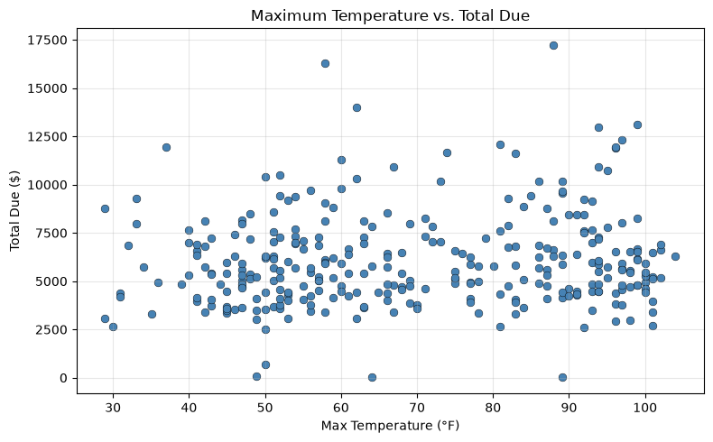

```python
df.plot.scatter(
    x='max_temp',
    y='TotalDue',
    title='Maximum Temperature vs. Total Due',
    figsize=(8, 5),
    alpha=1,
    color='steelblue',
    edgecolor='black',
    linewidth=0.3,
    s=40
)
plt.xlabel('Max Temperature (°F)')
plt.ylabel('Total Due ($)')
plt.grid(True, alpha=0.3)
plt.tight_layout()
plt.show()
```

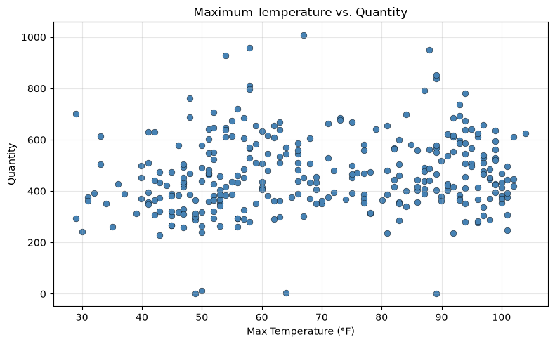

```python
df.plot.scatter(
    x='max_temp',
    y='Quantity',
    title='Maximum Temperature vs. Quantity',
    figsize=(8, 5),
    alpha=1,
    color='steelblue',
    edgecolor='black',
    linewidth=0.3,
    s=40
)
plt.xlabel('Max Temperature (°F)')
plt.ylabel('Quantity')
plt.grid(True, alpha=0.3)
plt.tight_layout()
plt.show()
```

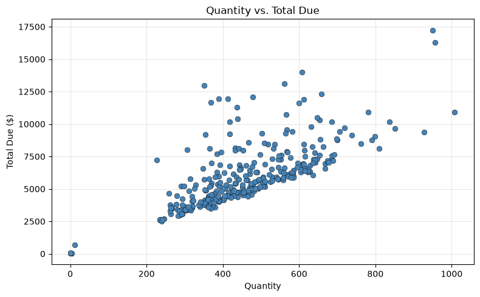

```python
df.plot.scatter(
    x='Quantity',
    y='TotalDue',
    title='Quantity vs. Total Due',
    figsize=(8, 5),
    alpha=1,
    color='steelblue',
    edgecolor='black',
    linewidth=0.3,
    s=40
)
plt.xlabel('Quantity')
plt.ylabel('Total Due ($)')
plt.grid(True, alpha=0.3)
plt.tight_layout()
plt.show()
```

Relationship Analysis

- Max_temp & TotalDue: There are no two way clear relationships between Max_temp and TotalDue. The points are spread out along the entire temperature range regardless of the TotalDue value, with no visible upward or downward slope. There are no noticeable upward or downward trend. On the more cool and warmer temperature days the total sales were above $15,000. This indicates that high sales is not depended on temperature but rather other factors like promotions, the days of the week, seasonal patterns and even spontaneous and unrelated to weather.
- Max_temp & Quantity: There are also no two way clear relationships between Max_temp and Quantity as the number if units that were sold regardless of temperature between ranges 0-1,000. Even on the highest sale days, the temperature ranged from moderate to high temperatures so again it indicated that temperature does’t directly correlate with how much gets sold.
- Quantity & TotalDue: Only this relationship between Quantity and TotalDue show a meaning positive relationship. As the quality goes up the TotalDue also goes up. This makes sense as selling more units means more total revenues; TotalDue is quantity*price. This trend shows the biggest sales days, for example 950-1000 units sold for between $16,000 to $17,000.

Summary: Of the three variable Pairs, we can conclude that high number of sales depend on how much quantity is sold naturally. And temperature has no directly relationship depending only on weather for high sales it the number of sales.